# House Price Prediction

### 2.2.1 Remove

Some variables(“PoolQC”, “MiscFeature”, “Alley”, “Fence”, “FireplaceQu”) have more than 20% of missing values. I simply remove them because there are too many missing values.

As for the variable “Utilities”, since 2916 houses are “AllPub” and only 1 house is “NoSeWa”, if we impute ‘AllPub’ for the 2 NAs, the variable will be useless for prediction because of lack of variation. So “Utilities” is also removed.

### 2.2.3 Fill with the most frequent factor

NAs in “Electrical”, “MSZoning” are filled with the most frequent type.

### 2.2.4 Fill with 0

NAs in “MasVnrArea”, “BsmtFullBath”, “BsmtHalfBath”, “BsmtFinSF1”, “BsmtFinSF2”, “BsmtUnfSF”, “TotalBsmtSF”, “GarageCars”, “GarageArea” are filled with 0.

### 2.2.5 Fill with guessed data

NAs in “GarageYrBlt” are filled with the year the house was built “YearBuilt”. NAs in “LotFrontage” are filled with the median of available values.

```r
var_names_na_to_none <- c("GarageType","GarageQual","GarageCond","GarageFinish", "BsmtExposure","BsmtFinType2","BsmtQual","BsmtCond","BsmtFinType1", "MasVnrType")
var_names_na_to_zero <- c("MasVnrArea", "BsmtFullBath", "BsmtHalfBath", "BsmtFinSF1", "BsmtFinSF2", "BsmtUnfSF", "TotalBsmtSF", "GarageCars", "GarageArea")
fill_with_highest_req <- c("MSZoning", "Functional", "Exterior1st", "Exterior2nd", "KitchenQual", "Electrical", "SaleType")

dataset_2 <- dataset %>%
  select(-c("PoolQC", "MiscFeature", "Alley", "Fence", "FireplaceQu", "Utilities")) %>%
  mutate_at(var_names_na_to_none, function(x) ifelse(is.na(x), "None", x)) %>%
  mutate(GarageYrBlt = ifelse(is.na(GarageYrBlt), YearBuilt, GarageYrBlt)) %>%
  mutate(LotFrontage = ifelse(is.na(LotFrontage), median(LotFrontage, na.rm = TRUE), LotFrontage)) %>%
  mutate_at(var_names_na_to_zero, function(x) ifelse(is.na(x), 0, x)) %>%
  mutate_at(fill_with_highest_req, function(x) ifelse(is.na(x), levels(x)[which.max(table(x))], x))
```

Now let’s verify that there is no NA left in the new data set.

```r
sapply(dataset_2, function(x) sum(is.na(x)))
```

```
##            Id    MSSubClass      MSZoning   LotFrontage       LotArea
##             0             0             0             0             0
##        Street      LotShape   LandContour     LotConfig     LandSlope
##             0             0             0             0             0
##  Neighborhood    Condition1    Condition2      BldgType    HouseStyle
##             0             0             0             0             0
##   OverallQual   OverallCond     YearBuilt  YearRemodAdd     RoofStyle
##             0             0             0             0             0
##      RoofMatl   Exterior1st   Exterior2nd    MasVnrType    MasVnrArea
##             0             0             0             0             0
##     ExterQual     ExterCond    Foundation      BsmtQual      BsmtCond
##             0             0             0             0             0
##  BsmtExposure  BsmtFinType1    BsmtFinSF1  BsmtFinType2    BsmtFinSF2
##             0             0             0             0             0
##     BsmtUnfSF   TotalBsmtSF       Heating     HeatingQC    CentralAir
##             0             0             0             0             0
##    Electrical     X1stFlrSF     X2ndFlrSF  LowQualFinSF     GrLivArea
##             0             0             0             0             0
##  BsmtFullBath  BsmtHalfBath      FullBath      HalfBath  BedroomAbvGr
##             0             0             0             0             0
##  KitchenAbvGr   KitchenQual  TotRmsAbvGrd    Functional    Fireplaces
##             0             0             0             0             0
##    GarageType   GarageYrBlt  GarageFinish    GarageCars    GarageArea
##             0             0             0             0             0
##    GarageQual    GarageCond    PavedDrive    WoodDeckSF   OpenPorchSF
##             0             0             0             0             0
## EnclosedPorch    X3SsnPorch   ScreenPorch      PoolArea       MiscVal
##             0             0             0             0             0
##        MoSold        YrSold      SaleType SaleCondition     SalePrice
##             0             0             0             0          1459
```

## 2.3 Preprocessing for analysis

### 2.3.1 Class of variables

We can see that some variables should be defined as class factor, but are now of class character.

```r
sapply(dataset_2, class)
```

```
##            Id    MSSubClass      MSZoning   LotFrontage       LotArea
##     "integer"     "integer"   "character"     "integer"     "integer"
##        Street      LotShape   LandContour     LotConfig     LandSlope
##      "factor"      "factor"      "factor"      "factor"      "factor"
##  Neighborhood    Condition1    Condition2      BldgType    HouseStyle
##      "factor"      "factor"      "factor"      "factor"      "factor"
##   OverallQual   OverallCond     YearBuilt  YearRemodAdd     RoofStyle
##     "integer"     "integer"     "integer"     "integer"      "factor"
##      RoofMatl   Exterior1st   Exterior2nd    MasVnrType    MasVnrArea
##      "factor"   "character"   "character"   "character"     "numeric"
##     ExterQual     ExterCond    Foundation      BsmtQual      BsmtCond
##      "factor"      "factor"      "factor"   "character"   "character"
##  BsmtExposure  BsmtFinType1    BsmtFinSF1  BsmtFinType2    BsmtFinSF2
##   "character"   "character"     "numeric"   "character"     "numeric"
##     BsmtUnfSF   TotalBsmtSF       Heating     HeatingQC    CentralAir
##     "numeric"     "numeric"      "factor"      "factor"      "factor"
##    Electrical     X1stFlrSF     X2ndFlrSF  LowQualFinSF     GrLivArea
##   "character"     "integer"     "integer"     "integer"     "integer"
##  BsmtFullBath  BsmtHalfBath      FullBath      HalfBath  BedroomAbvGr
##     "numeric"     "numeric"     "integer"     "integer"     "integer"
##  KitchenAbvGr   KitchenQual  TotRmsAbvGrd    Functional    Fireplaces
##     "integer"   "character"     "integer"   "character"     "integer"
##    GarageType   GarageYrBlt  GarageFinish    GarageCars    GarageArea
##   "character"     "integer"   "character"     "numeric"     "numeric"
##    GarageQual    GarageCond    PavedDrive    WoodDeckSF   OpenPorchSF
##   "character"   "character"      "factor"     "integer"     "integer"
## EnclosedPorch    X3SsnPorch   ScreenPorch      PoolArea       MiscVal
##     "integer"     "integer"     "integer"     "integer"     "integer"
##        MoSold        YrSold      SaleType SaleCondition     SalePrice
##     "integer"     "integer"   "character"      "factor"     "integer"
```

So we need to change their class into factor.

```r
var_names_to_type_factor <- c("MSSubClass", "MSZoning", "OverallQual", "OverallCond", "YearBuilt", "YearRemodAdd", "Exterior1st", "Exterior2nd", "MoSold", "YrSold", "MasVnrType", "BsmtCond", "BsmtExposure", "BsmtFinType1", "BsmtFinType2", "BsmtQual", "Electrical", "KitchenQual", "Functional", "GarageType", "GarageYrBlt", "GarageFinish", "GarageQual", "GarageCond", "SaleType")

dataset_3 <- dataset_2 %>% mutate_at(var_names_to_type_factor, function(x) as.factor(x))
```

Now let’s verify that all variables are of the right class.

```r
sapply(dataset_3, class)
```

```
##            Id    MSSubClass      MSZoning   LotFrontage       LotArea
##     "integer"      "factor"      "factor"     "integer"     "integer"
##        Street      LotShape   LandContour     LotConfig     LandSlope
##      "factor"      "factor"      "factor"      "factor"      "factor"
##  Neighborhood    Condition1    Condition2      BldgType    HouseStyle
##      "factor"      "factor"      "factor"      "factor"      "factor"
##   OverallQual   OverallCond     YearBuilt  YearRemodAdd     RoofStyle
##      "factor"      "factor"      "factor"      "factor"      "factor"
##      RoofMatl   Exterior1st   Exterior2nd    MasVnrType    MasVnrArea
##      "factor"      "factor"      "factor"      "factor"     "numeric"
##     ExterQual     ExterCond    Foundation      BsmtQual      BsmtCond
##      "factor"      "factor"      "factor"      "factor"      "factor"
##  BsmtExposure  BsmtFinType1    BsmtFinSF1  BsmtFinType2    BsmtFinSF2
##      "factor"      "factor"     "numeric"      "factor"     "numeric"
##     BsmtUnfSF   TotalBsmtSF       Heating     HeatingQC    CentralAir
##     "numeric"     "numeric"      "factor"      "factor"      "factor"
##    Electrical     X1stFlrSF     X2ndFlrSF  LowQualFinSF     GrLivArea
##      "factor"     "integer"     "integer"     "integer"     "integer"
##  BsmtFullBath  BsmtHalfBath      FullBath      HalfBath  BedroomAbvGr
##     "numeric"     "numeric"     "integer"     "integer"     "integer"
##  KitchenAbvGr   KitchenQual  TotRmsAbvGrd    Functional    Fireplaces
##     "integer"      "factor"     "integer"      "factor"     "integer"
##    GarageType   GarageYrBlt  GarageFinish    GarageCars    GarageArea
##      "factor"      "factor"      "factor"     "numeric"     "numeric"
##    GarageQual    GarageCond    PavedDrive    WoodDeckSF   OpenPorchSF
##      "factor"      "factor"      "factor"     "integer"     "integer"
## EnclosedPorch    X3SsnPorch   ScreenPorch      PoolArea       MiscVal
##     "integer"     "integer"     "integer"     "integer"     "integer"
##        MoSold        YrSold      SaleType SaleCondition     SalePrice
##      "factor"      "factor"      "factor"      "factor"     "integer"
```

### 2.3.2 Normalize the numeric variables

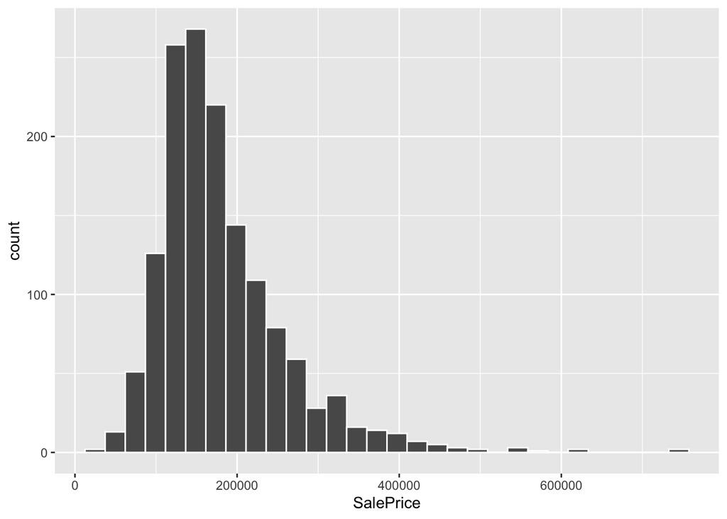

```r
dataset_3 %>% ggplot(aes(SalePrice)) +
  geom_histogram(color = "white")
```

We use skewness to measure the data set’s degree of deviation from a symmetrical distribution.

```r
skewness(dataset_3$SalePrice, na.rm = TRUE)
```

```
## [1] 1.880941
```

In order to fix the skewness, we take the log for SalePrice. Now we can see that the skewness is closer to 0.

```r
skewness(log(dataset_3$SalePrice), na.rm = TRUE)
```

```
## [1] 0.1212104
```

There are other numeric predictors that also need to be normalized. I calculate the skewness of the predictors and find the ones with skewness larger than 0.8 or smaller than -0.8.

```r
index_numeric <- which(sapply(dataset_3, is.numeric))

numeric_predictors <- dataset_3[index_numeric]
numeric_predictors <- numeric_predictors[, -which(colnames(numeric_predictors) %in% c("Id","SalePrice"))]
predictors_skewness <- sapply(numeric_predictors, skewness)
vars_to_normalize <- names(predictors_skewness[abs(predictors_skewness) > 0.8])
vars_to_normalize
```

```
##  [1] "LotFrontage"   "LotArea"       "MasVnrArea"    "BsmtFinSF1"
##  [5] "BsmtFinSF2"    "BsmtUnfSF"     "TotalBsmtSF"   "X1stFlrSF"
##  [9] "X2ndFlrSF"     "LowQualFinSF"  "GrLivArea"     "BsmtHalfBath"
## [13] "KitchenAbvGr"  "WoodDeckSF"    "OpenPorchSF"   "EnclosedPorch"
## [17] "X3SsnPorch"    "ScreenPorch"   "PoolArea"      "MiscVal"
```

I fix the skewness by taking log+1 for the predictors.

```r
dataset_4 <- dataset_3 %>%
  mutate_at(vars_to_normalize, function(x) log(x+1))

train_set_4 <- dataset_4[!is.na(dataset_4$SalePrice), ]
test_set_4 <- dataset_4[is.na(dataset_4$SalePrice), ]
```

# 3 Analysis

Predictive models are built using random forest, Lasso, and GBDT algorithm. A stacked model is also built using the average of the previous three models.

## 3.1 Random Forest

```r
control <- trainControl(method = "cv", number = 5, verboseIter = FALSE)
set.seed(40)
train_rf <- train(log(SalePrice)~ .-Id, data = train_set_4,  method = "Rborist",  trControl = control,  tuneGrid = data.frame(predFixed = 2, minNode = c(3, 5, 10, 25, 50)))

y_train <- log(train_set_4$SalePrice)
x_train <- train_set_4 %>% select(-c("Id", "SalePrice"))
fit_rf <- Rborist(x_train, y_train, minNode = 3)

x_test <- test_set_4 %>% select(-c("Id", "SalePrice"))
y_predict_rf <- predict(fit_rf, x_test)
y_hat_rf <- exp(y_predict_rf[["yPred"]])

sub_rf <- data.frame(Id = test_set$Id, SalePrice = y_hat_rf)
write.csv(sub_rf, file = "sub_rf_2.csv", row.names = FALSE)
```

## 3.2 Lasso

```r
x_train_lasso <- model.matrix(as.formula( log(SalePrice)~ .-Id ), train_set_4)

set.seed(40)
fit_lasso <- cv.glmnet(x_train_lasso, y_train, alpha=1)
test_set_4$SalePrice <- 1
x_test_lasso <- model.matrix(as.formula( log(SalePrice)~ .-Id ), test_set_4)
y_predict_lasso <- predict(fit_lasso, newx = x_test_lasso, s = "lambda.min")
y_hat_lasso <- exp(as.numeric(y_predict_lasso))

sub_lasso <- data.frame(Id = test_set$Id, SalePrice = y_hat_lasso)
write.csv(sub_lasso, file = "sub_lasso.csv", row.names = FALSE)
```

## 3.3 GBDT

```r
train_gbdt <- train(log(SalePrice)~ .-Id, data = train_set_4,  method = "gbm",  trControl = control)
y_predict_gbdt <- predict(train_gbdt, test_set_4)
y_hat_gbdt <- exp(y_predict_gbdt)
sub_gbdt <- data.frame(Id = test_set$Id, SalePrice = y_hat_gbdt)
write.csv(sub_gbdt, file = "sub_gbdt.csv", row.names = FALSE)
```

## 3.4 Average the random forest, lasso and gbdt model

```r
y_predict_rf_lasso_gbdt <- (y_hat_rf + y_hat_lasso + y_hat_gbdt)/3
sub_rf_lasso_gbdt <- data.frame(Id = test_set$Id, SalePrice = y_predict_rf_lasso_gbdt)
write.csv(sub_rf_lasso_gbdt, file = "sub_rf_lasso_gbdt.csv", row.names = FALSE)
```

# 4 Results

We can see the result of the four models by submitting our predictions to the website. The result is as follows.

| method | RMSE |
| --- | --- |
| RF | 0.21088 |
| Lasso | 0.13506 |
| GBDT | 0.14421 |
| Stacked | 0.14675 |

The Lasso model generates the most precise prediction.

# 5 Conclusion

In the report, four models are built using different algorithms and their performances are compared. We carefully clean the data set and organize it to fit with the models.

I believe the result can be further improved by 3 methods: 1)better selection of model parameters; 2) feature engineering; 3) try other algorithms.